# CF

vey

17/12/2020

# **LE** **CONSEIL** **FEDERAL** **EN** **CHIFFRES**

## **DEPUIS** **1848**

### Nombre d’années passées au Conseil fédéral

Le Bernois Karl Schenk est le recordman dans le domaine

| Name | Kanton | Gewählt | partei | duree | deces_pouvoir |
| --- | --- | --- | --- | --- | --- |
| Schenk, Karl | BE | 1863-12-12 | FDP | 31.62 | Oui |
| Deucher, Adolf | TG | 1883-04-10 | FDP | 29.27 | Oui |
| Motta, Giuseppe | TI | 1911-12-14 | CVP | 28.13 | Oui |
| Naeff, Wilhelm Math. | SG | 1848-11-16 | FDP | 27.14 | Non |
| Etter, Philipp | ZG | 1934-03-28 | CVP | 25.66 | Non |
| Welti, Emil | AG | 1866-12-08 | FDP | 25.08 | Non |
| Schulthess, Edmund | AG | 1912-07-17 | FDP | 22.76 | Non |
| Knüsel, Josef Martin | LU | 1855-07-14 | FDP | 20.48 | Non |
| Frey-Herosee, Friedrich | AG | 1848-11-16 | FDP | 18.13 | Non |
| Droz, Numa | NE | 1875-12-18 | FDP | 17.01 | Non |
| Petitpierre, Max | NE | 1944-12-14 | FDP | 16.55 | Non |
| Zemp, Joseph | LU | 1891-12-17 | CVP | 16.51 | Non |
| Pilet-Golaz, Marcel | VD | 1928-12-13 | FDP | 15.91 | Non |
| Müller, Eduard | BE | 1895-08-16 | FDP | 15.58 | Non |
| Leuenberger, Moritz | ZH | 1995-09-27 | SP | 15.10 | Non |
| Hammer, Bernhard | SO | 1875-12-10 | FDP | 15.07 | Non |
| Furgler, Kurt | SG | 1971-12-08 | CVP | 15.07 | Non |
| Forrer, Ludwig | ZH | 1902-12-11 | FDP | 15.00 | Non |
| Villiger, Kaspar | LU | 1989-02-01 | FDP | 14.92 | Non |
| Musy, Jean-Marie | FR | 1919-12-11 | CVP | 14.39 | Non |

**Nombre** **de** **conseillers** **fédéraux** **par** **canton**

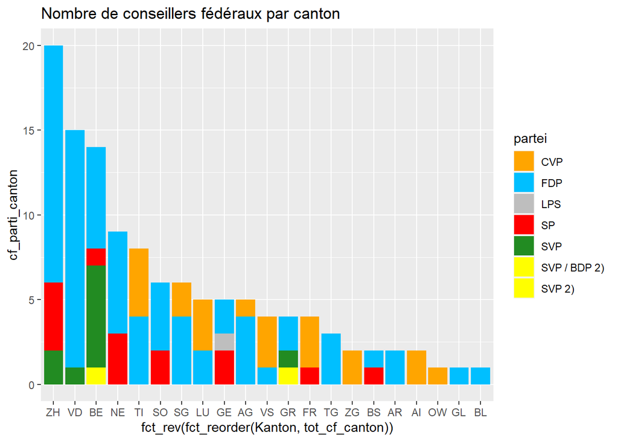

| Kanton | partei | tot_cf_canton | cf_parti_canton |
| --- | --- | --- | --- |
| ZH | FDP | 20 | 14 |
| ZH | SP | 20 | 4 |
| ZH | SVP | 20 | 2 |
| VD | FDP | 15 | 14 |
| VD | SVP | 15 | 1 |
| BE | FDP | 14 | 6 |
| BE | SVP | 14 | 6 |
| BE | SP | 14 | 1 |
| BE | SVP 2) | 14 | 1 |
| NE | FDP | 9 | 6 |
| NE | SP | 9 | 3 |
| TI | CVP | 8 | 4 |
| TI | FDP | 8 | 4 |
| SG | FDP | 6 | 4 |
| SO | FDP | 6 | 4 |
| SG | CVP | 6 | 2 |
| SO | SP | 6 | 2 |
| AG | FDP | 5 | 4 |
| LU | CVP | 5 | 3 |
| GE | FDP | 5 | 2 |
| GE | SP | 5 | 2 |
| LU | FDP | 5 | 2 |
| AG | CVP | 5 | 1 |
| GE | LPS | 5 | 1 |
| FR | CVP | 4 | 3 |
| VS | CVP | 4 | 3 |
| GR | FDP | 4 | 2 |
| FR | SP | 4 | 1 |
| GR | SVP | 4 | 1 |
| GR | SVP / BDP 2) | 4 | 1 |
| VS | FDP | 4 | 1 |
| TG | FDP | 3 | 3 |
| AI | CVP | 2 | 2 |
| AR | FDP | 2 | 2 |
| ZG | CVP | 2 | 2 |
| BS | FDP | 2 | 1 |
| BS | SP | 2 | 1 |
| BL | FDP | 1 | 1 |
| GL | FDP | 1 | 1 |
| OW | CVP | 1 | 1 |

**Conseillers** **fédéraux** **les** **plus** **jeunes** **et** **les** **plus** **âgés** **lors** **de** **leur** **élection**

*Les* *plus* *jeunes* Si plusieurs ont été élus au même âge, faire une recherche complémentaire pour savoir qui était le plus jeune d’entre eux

| Name | Bürgerort | Kanton | partei | age_elec | Gewählt |
| --- | --- | --- | --- | --- | --- |
| Droz, Numa | La Chaux-de-Fonds | NE | FDP | 31 | 1875-12-18 |
| Stämpfli, Jakob | Schwanden | BE | FDP | 34 | 1854-12-06 |
| Metzler-Arnold, Ruth | Willisau, Richenthal und Balgach | AI | CVP | 35 | 1999-03-11 |
| Fornerod, Constant | Avenches | VD | FDP | 36 | 1855-07-11 |
| Ochsenbein, Ulrich | Nidau | BE | FDP | 37 | 1848-11-16 |
| Borel, Eugène | Neuchâtel | NE | FDP | 37 | 1872-12-07 |
| Ceresole, Paul | Vevey | VD | FDP | 38 | 1870-02-01 |
| Dubs, Jakob | Affoltern | ZH | FDP | 39 | 1861-07-30 |
| Ruffy, Eugène | Lutry | VD | FDP | 39 | 1893-12-14 |
| Pilet-Golaz, Marcel | Château-d’Oex | VD | FDP | 39 | 1928-12-13 |
| Berset, Alain | Misery-Courtion | FR | SP | 39 | 2011-12-14 |
| Schenk, Karl | Signau | BE | FDP | 40 | 1863-12-12 |
| Motta, Giuseppe | Airolo | TI | CVP | 40 | 1911-12-14 |
| Welti, Emil | Zurzach | AG | FDP | 41 | 1866-12-08 |
| Brenner, Ernst | Basel | BS | FDP | 41 | 1897-03-25 |
| Knüsel, Josef Martin | Luzern | LU | FDP | 42 | 1855-07-14 |
| Furrer, Jonas | Winterthur | ZH | FDP | 43 | 1848-11-16 |
| Lachenal, Adrien | Genève | GE | FDP | 43 | 1892-12-15 |
| Musy, Jean-Marie | Albeuve | FR | CVP | 43 | 1919-12-11 |
| Etter, Philipp | Menzingen | ZG | CVP | 43 | 1934-03-28 |

*Les* *plus* *âgés* Si plusieurs ont été élus au même âge, faire une recherche complémentaire pour savoir qui était le plus vieux d’entre eux

| Name | Bürgerort | Kanton | partei | age_elec | Gewählt | deces_pouvoir |
| --- | --- | --- | --- | --- | --- | --- |
| Ador, Gustave | Genève | GE | LPS | 72 | 1917-06-26 | Non |
| Escher, Josef | Simplon-Dorf | VS | CVP | 65 | 1950-09-14 | Non |
| Perrier, Louis | Ste-Croix et Neuchâtel | NE | FDP | 63 | 1912-03-12 | Oui |
| Blocher, Christoph | Meilen, Zürich, Schattenhalb | ZH | SVP | 63 | 2003-12-10 | Non |
| Chuard, Ernest | Corcelles s. Payerne | VD | FDP | 62 | 1919-12-11 | Non |
| Wetter, Ernst | Winterthur | ZH | FDP | 61 | 1938-12-15 | Non |
| Streuli, Hans | Wädenswil u. Richterswil | ZH | FDP | 61 | 1953-12-22 | Non |
| Graber, Pierre | Langenbruck und La Chaux-de-Fonds | NE | SP | 61 | 1969-12-10 | Non |
| Merz, Hans-Rudolf | Beinwil am See | AR | FDP | 61 | 2003-12-10 | Non |
| Baumann, Johannes | Herisau | AR | FDP | 60 | 1934-03-22 | Non |
| Honegger, Fritz | Fischenthal u. Rüschlikon | ZH | FDP | 60 | 1977-12-07 | Non |
| Schobinger, Josef Anton | Luzern | LU | CVP | 59 | 1908-06-17 | Oui |
| Meyer, Albert | Fällanden u. Zürich | ZH | FDP | 59 | 1929-12-12 | Non |
| von Steiger, Eduard | Bern u. Langnau i. E. | BE | SVP | 59 | 1940-12-10 | Non |
| Wahlen, Friedrich Traugott | Trimstein u. Bern | BE | SVP | 59 | 1958-12-11 | Non |
| Friedrich, Rudolf | Winterthur | ZH | FDP | 59 | 1982-12-08 | Non |
| Holenstein, Thomas | Bütschwil | SG | CVP | 58 | 1954-12-16 | Non |
| Chevallaz, Georges-André | Montherod | VD | FDP | 58 | 1973-12-05 | Non |
| Egli, Alphons | Entlebuch u. Luzern | LU | CVP | 58 | 1982-12-08 | Non |
| Maurer, Ueli | Adelboden, Hinwil | ZH | SVP | 58 | 2008-12-10 | Non |

**Age** **lors** **de** **la** **démission** **ou** **non-rélection**

*Les* *plus* *jeunes* Si plusieurs ont démissionné au même âge, faire une recherche complémentaire pour savoir qui était le plus jeune d’entre eux Attention, les conseillers fédéraux encore au pouvoir figurent dans ce classement

| Name | Geboren | Bürgerort | Kanton | partei | age_dep |
| --- | --- | --- | --- | --- | --- |
| Metzler-Arnold, Ruth | 1964 | Willisau, Richenthal und Balgach | AI | CVP | 39 |
| Borel, Eugène | 1835 | Neuchâtel | NE | FDP | 40 |
| Ochsenbein, Ulrich | 1811 | Nidau | BE | FDP | 43 |
| Stämpfli, Jakob | 1820 | Schwanden | BE | FDP | 43 |
| Ceresole, Paul | 1832 | Vevey | VD | FDP | 43 |
| Ruffy, Eugène | 1854 | Lutry | VD | FDP | 45 |
| Ruffy, Victor | 1823 | Lutry | VD | FDP | 46 |
| Brenner, Ernst | 1856 | Basel | BS | FDP | 46 |
| Fornerod, Constant | 1819 | Avenches | VD | FDP | 48 |
| Droz, Numa | 1844 | La Chaux-de-Fonds | NE | FDP | 48 |
| Berset, Alain | 1972 | Misery-Courtion | FR | SP | 49 |
| Dubs, Jakob | 1822 | Affoltern | ZH | FDP | 50 |
| Lachenal, Adrien | 1849 | Genève | GE | FDP | 50 |
| Anderwert, Fridolin | 1828 | Emmishofen | TG | FDP | 52 |
| Scherer, Johann Jakob | 1825 | Winterthur | ZH | FDP | 53 |
| Heer, Joachim | 1825 | Glarus | GL | FDP | 53 |
| Kopp, Elisabeth | 1936 | Niederönz, Luzern und Zumikon | ZH | FDP | 53 |
| Pilet-Golaz, Marcel | 1889 | Château-d’Oex | VD | FDP | 55 |
| Leuthard, Doris | 1963 | Merenschwand, Sarnen | AG | CVP | 55 |
| Furrer, Jonas | 1805 | Winterthur | ZH | FDP | 56 |

*Les* *plus* *âgés* Si plusieurs ont démissionné au même âge, faire une recherche complémentaire pour savoir qui était le plus vieux d’entre eux Attention, les conseillers fédéraux encore au pouvoir figurent dans ce classement

| Name | Geboren | Bürgerort | Kanton | partei | age_dep |
| --- | --- | --- | --- | --- | --- |
| Deucher, Adolf | 1831 | Steckborn | TG | FDP | 81 |
| Zemp, Joseph | 1834 | Entlebuch | LU | CVP | 74 |
| Ador, Gustave | 1845 | Genève | GE | LPS | 74 |
| Naeff, Wilhelm Math. | 1802 | Altstätten | SG | FDP | 73 |
| Schenk, Karl | 1823 | Signau | BE | FDP | 72 |
| Forrer, Ludwig | 1845 | Bäretswil u. Winterthur | ZH | FDP | 72 |
| Chuard, Ernest | 1857 | Corcelles s. Payerne | VD | FDP | 71 |
| Maurer, Ueli | 1950 | Adelboden, Hinwil | ZH | SVP | 71 |
| von Steiger, Eduard | 1881 | Bern u. Langnau i. E. | BE | SVP | 70 |
| Graber, Pierre | 1908 | Langenbruck und La Chaux-de-Fonds | NE | SP | 70 |
| Motta, Giuseppe | 1871 | Airolo | TI | CVP | 69 |
| Escher, Josef | 1885 | Simplon-Dorf | VS | CVP | 69 |
| Hammer, Bernhard | 1822 | Olten | SO | FDP | 68 |
| Meyer, Albert | 1870 | Fällanden u. Zürich | ZH | FDP | 68 |
| Etter, Philipp | 1891 | Menzingen | ZG | CVP | 68 |
| Spühler, Willy | 1902 | Zürich | ZH | SP | 68 |
| Chevallaz, Georges-André | 1915 | Montherod | VD | FDP | 68 |
| Stich, Otto | 1927 | Kleinlützel | SO | SP | 68 |
| Merz, Hans-Rudolf | 1942 | Beinwil am See | AR | FDP | 68 |
| Schulthess, Edmund | 1868 | Brugg | AG | FDP | 67 |

**Le** **plus** **longtemps** **dans** **un** **département**

A prendre avec des pincettes car les calculs se basent sur des chiffres arrondis à l’année figurant sur le site de la Chancellerie fédérale. La tendance est correcte mais peut-être pas le chiffre exact.

| Name | Kanton | partei | Dep | duree |
| --- | --- | --- | --- | --- |
| Etter, Philipp | ZG | CVP | DFI | 26 |
| Schenk, Karl | BE | FDP | DFI | 24 |
| Motta, Giuseppe | TI | CVP | DFAE | 21 |
| Schulthess, Edmund | AG | FDP | DEFR | 20 |
| Petitpierre, Max | NE | FDP | DFAE | 17 |
| Zemp, Joseph | LU | CVP | DETEC | 16 |
| Leuenberger, Moritz | ZH | SP | DETEC | 16 |
| Häberlin, Heinrich | TG | FDP | DFJP | 15 |
| Musy, Jean-Marie | FR | CVP | DFF | 15 |
| Droz, Numa | NE | FDP | DEFR | 14 |
| Hammer, Bernhard | SO | FDP | DFF | 14 |
| Tschudi, Hans-Peter | BS | SP | DFI | 14 |
| Müller, Eduard | BE | FDP | DDPS | 13 |
| Brenner, Ernst | BS | FDP | DFJP | 13 |
| Haab, Robert | ZH | FDP | DETEC | 12 |
| Chaudet, Paul | VD | FDP | DDPS | 12 |
| Gnägi, Rudolf | BE | SVP | DDPS | 12 |
| Delamuraz, Jean-Pascal | VD | FDP | DEFR | 12 |
| von Moos, Ludwig | OW | CVP | DFJP | 12 |
| Stich, Otto | SO | SP | DFF | 12 |

**Durée moyenne d’un conseiller fédéral en fonction d’un parti**

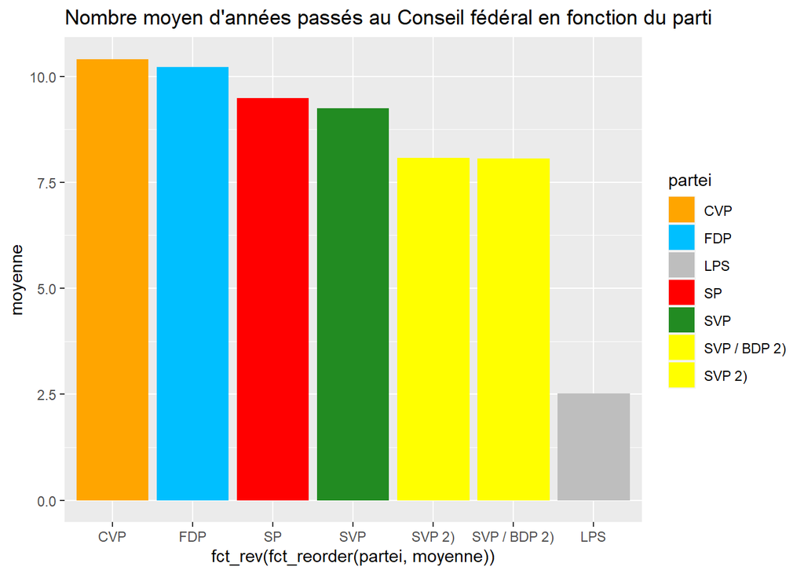

| partei | moyenne |
| --- | --- |
| CVP | 10.409048 |
| FDP | 10.220563 |
| SP | 9.489286 |
| SVP | 9.250000 |
| SVP 2) | 8.070000 |
| SVP / BDP 2) | 8.060000 |
| LPS | 2.520000 |

## **DEPUIS L’INTRODUCTION DE LA FORMULE MAGIQUE** (LE 17 DECEMBRE 1959, DONC DEPUIS DEBUT 1960)

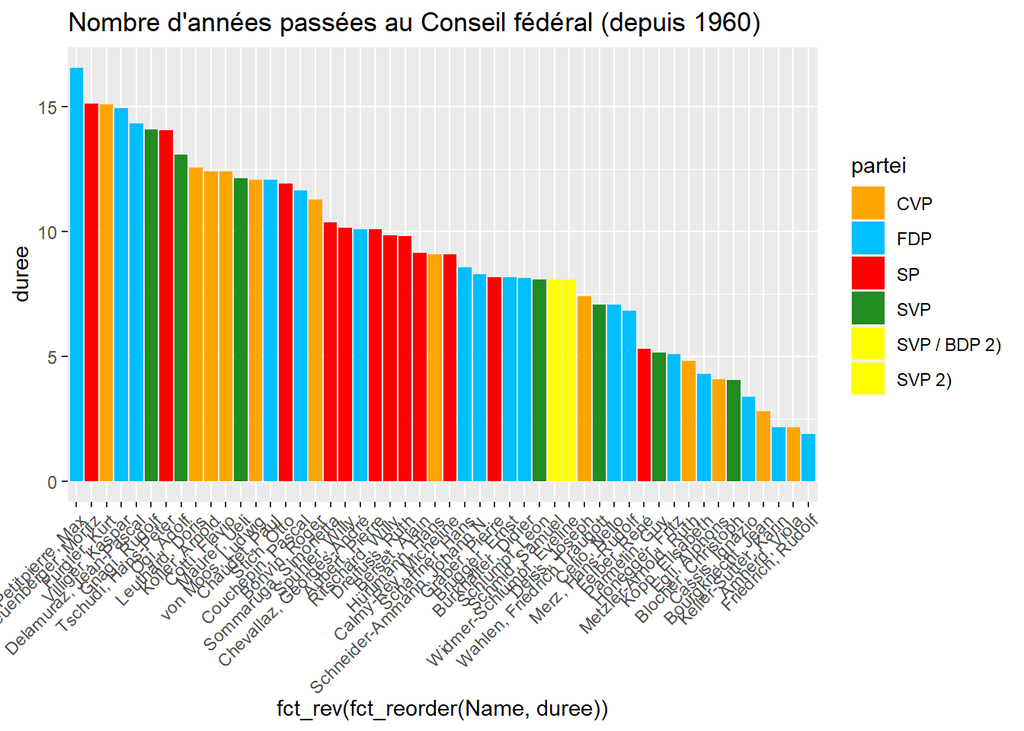

| Name | Kanton | partei | duree | deces_pouvoir | Gewählt | Zurückgetreten | Gestorben | Geboren | Bürgerort |
| --- | --- | --- | --- | --- | --- | --- | --- | --- | --- |
| Petitpierre, Max | NE | FDP | 16.55 | Non | 1944-12-14 | 1961-06-30 | 1994-03-25 | 1899 | Neuchâtel et Couvet |
| Leuenberger, Moritz | ZH | SP | 15.10 | Non | 1995-09-27 | 2010-10-31 | NA | 1946 | Rohrbach |
| Furgler, Kurt | SG | CVP | 15.07 | Non | 1971-12-08 | 1986-12-31 | 2008-07-23 | 1924 | Valens u. Pfäfers |
| Villiger, Kaspar | LU | FDP | 14.92 | Non | 1989-02-01 | 2003-12-31 | NA | 1941 | Sins und Pfeffikon |
| Delamuraz, Jean-Pascal | VD | FDP | 14.32 | Non | 1983-12-07 | 1998-03-30 | 1998-10-04 | 1936 | Longirod |
| Gnägi, Rudolf | BE | SVP | 14.07 | Non | 1965-12-08 | 1979-12-31 | 1985-04-20 | 1917 | Schwadernau |
| Tschudi, Hans-Peter | BS | SP | 14.05 | Non | 1959-12-17 | 1973-12-31 | 2002-09-30 | 1913 | Schwanden u. Basel |
| Ogi, Adolf | BE | SVP | 13.07 | Non | 1987-12-09 | 2000-12-31 | NA | 1942 | Kandersteg |
| Leuthard, Doris | AG | CVP | 12.56 | Non | 2006-06-14 | 2018-12-31 | NA | 1963 | Merenschwand, Sarnen |
| Koller, Arnold | AI | CVP | 12.39 | Non | 1986-12-10 | 1999-04-30 | NA | 1933 | Gossau u. Oberbüren |
| Cotti, Flavio | TI | CVP | 12.39 | Non | 1986-12-10 | 1999-04-30 | NA | 1939 | Prato Sornico |
| Maurer, Ueli | ZH | SVP | 12.14 | Non | 2008-12-10 | 2021-01-27 | NA | 1950 | Adelboden, Hinwil |
| Chaudet, Paul | VD | FDP | 12.05 | Non | 1954-12-16 | 1966-12-31 | 1977-08-07 | 1904 | Corsier s. Vevey |
| von Moos, Ludwig | OW | CVP | 12.05 | Non | 1959-12-17 | 1971-12-31 | 1990-11-26 | 1910 | Sachseln |
| Stich, Otto | SO | SP | 11.91 | Non | 1983-12-07 | 1995-10-31 | 2012-09-12 | 1927 | Kleinlützel |
| Couchepin, Pascal | VS | FDP | 11.65 | Non | 1998-03-11 | 2009-10-31 | NA | 1942 | Martigny |
| Bonvin, Roger | VS | CVP | 11.27 | Non | 1962-09-27 | 1973-12-31 | 1982-06-05 | 1907 | Icogne-Lens, Chermignon et Nendaz |
| Sommaruga, Simonetta | BE | SP | 10.36 | Non | 2010-09-22 | 2021-01-27 | NA | 1960 | Lugano, Eggiwil |
| Spühler, Willy | ZH | SP | 10.13 | Non | 1959-12-17 | 1970-01-31 | 1990-05-31 | 1902 | Zürich |
| Chevallaz, Georges-André | VD | FDP | 10.08 | Non | 1973-12-05 | 1983-12-31 | 2002-09-08 | 1915 | Montherod |

**Nombre** **de** **conseillers** **fédéraux** **par** **canton**

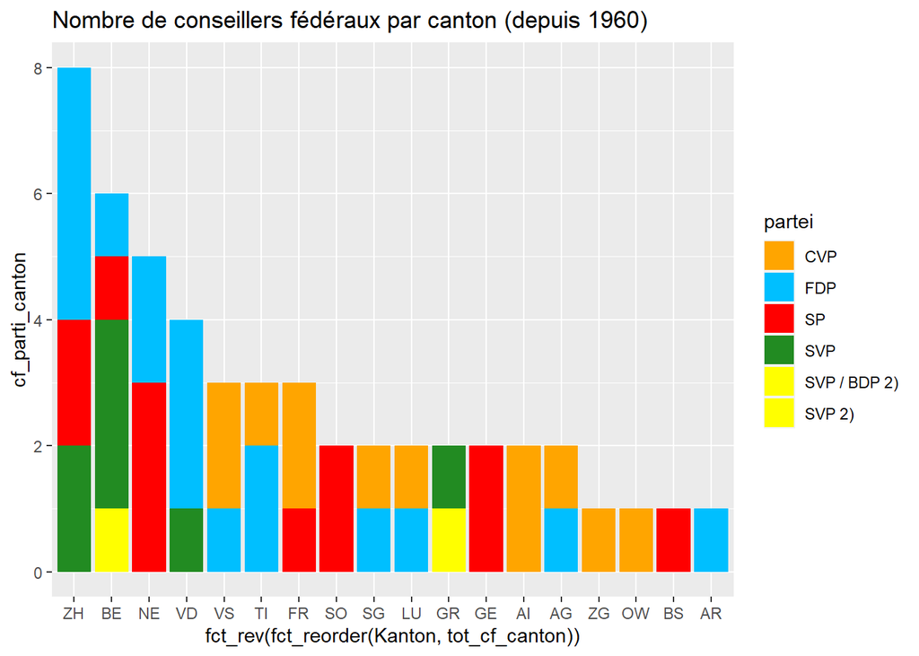

**Age lors de l’élection**

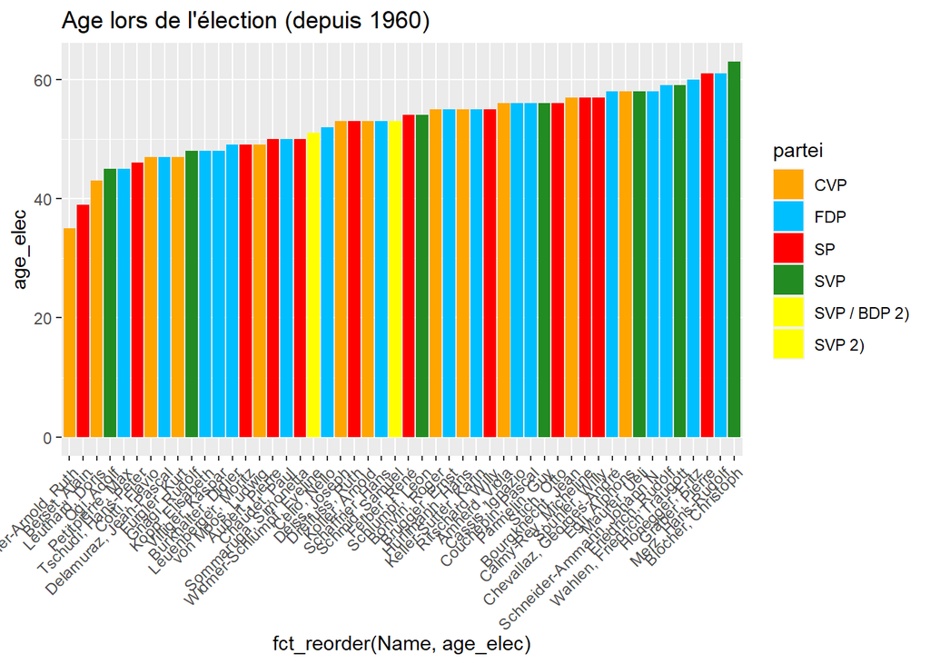

*Les plus jeunes* Si plusieurs ont été élus au même âge, faire une recherche complémentaire pour savoir qui était le plus jeune d’entre eux

| Name | Bürgerort | Kanton | partei | age_elec | Gewählt |
| --- | --- | --- | --- | --- | --- |
| Metzler-Arnold, Ruth | Willisau, Richenthal und Balgach | AI | CVP | 35 | 1999-03-11 |
| Berset, Alain | Misery-Courtion | FR | SP | 39 | 2011-12-14 |
| Leuthard, Doris | Merenschwand, Sarnen | AG | CVP | 43 | 2006-06-14 |
| Petitpierre, Max | Neuchâtel et Couvet | NE | FDP | 45 | 1944-12-14 |
| Ogi, Adolf | Kandersteg | BE | SVP | 45 | 1987-12-09 |
| Tschudi, Hans-Peter | Schwanden u. Basel | BS | SP | 46 | 1959-12-17 |
| Furgler, Kurt | Valens u. Pfäfers | SG | CVP | 47 | 1971-12-08 |
| Delamuraz, Jean-Pascal | Longirod | VD | FDP | 47 | 1983-12-07 |
| Cotti, Flavio | Prato Sornico | TI | CVP | 47 | 1986-12-10 |
| Gnägi, Rudolf | Schwadernau | BE | SVP | 48 | 1965-12-08 |
| Kopp, Elisabeth | Niederönz, Luzern und Zumikon | ZH | FDP | 48 | 1984-10-02 |
| Villiger, Kaspar | Sins und Pfeffikon | LU | FDP | 48 | 1989-02-01 |
| von Moos, Ludwig | Sachseln | OW | CVP | 49 | 1959-12-17 |
| Leuenberger, Moritz | Rohrbach | ZH | SP | 49 | 1995-09-27 |
| Burkhalter, Didier | Neuchâtel, Sumiswald | NE | FDP | 49 | 2009-09-16 |
| Chaudet, Paul | Corsier s. Vevey | VD | FDP | 50 | 1954-12-16 |
| Aubert, Pierre | Savagnier | NE | SP | 50 | 1977-12-07 |
| Sommaruga, Simonetta | Lugano, Eggiwil | BE | SP | 50 | 2010-09-22 |
| Widmer-Schlumpf, Eveline | Felsberg, Mönchaltorf | GR | SVP / BDP 2) | 51 | 2007-12-12 |
| Celio, Nello | Quinto (Lev.) | TI | FDP | 52 | 1966-12-15 |

*Les plus vieux* Si plusieurs ont été élus au même âge, faire une recherche complémentaire pour savoir qui était le plus vieux d’entre eux

| Name | Bürgerort | Kanton | partei | age_elec | Gewählt | deces_pouvoir |
| --- | --- | --- | --- | --- | --- | --- |
| Blocher, Christoph | Meilen, Zürich, Schattenhalb | ZH | SVP | 63 | 2003-12-10 | Non |
| Graber, Pierre | Langenbruck und La Chaux-de-Fonds | NE | SP | 61 | 1969-12-10 | Non |
| Merz, Hans-Rudolf | Beinwil am See | AR | FDP | 61 | 2003-12-10 | Non |
| Honegger, Fritz | Fischenthal u. Rüschlikon | ZH | FDP | 60 | 1977-12-07 | Non |
| Wahlen, Friedrich Traugott | Trimstein u. Bern | BE | SVP | 59 | 1958-12-11 | Non |
| Friedrich, Rudolf | Winterthur | ZH | FDP | 59 | 1982-12-08 | Non |
| Chevallaz, Georges-André | Montherod | VD | FDP | 58 | 1973-12-05 | Non |
| Egli, Alphons | Entlebuch u. Luzern | LU | CVP | 58 | 1982-12-08 | Non |
| Maurer, Ueli | Adelboden, Hinwil | ZH | SVP | 58 | 2008-12-10 | Non |
| Schneider-Ammann, Johann N. | Hasle bei Burgdorf | BE | FDP | 58 | 2010-09-22 | Non |
| Bourgknecht, Jean | Fribourg | FR | CVP | 57 | 1959-12-17 | Non |
| Spühler, Willy | Zürich | ZH | SP | 57 | 1959-12-17 | Non |
| Calmy-Rey, Micheline | Chermignon | GE | SP | 57 | 2002-12-04 | Non |
| Stich, Otto | Kleinlützel | SO | SP | 56 | 1983-12-07 | Non |
| Couchepin, Pascal | Martigny | VS | FDP | 56 | 1998-03-11 | Non |
| Parmelin, Guy | Bursins | VD | SVP | 56 | 2015-12-09 | Non |
| Cassis, Ignazio | Biasca, Sessa | TI | FDP | 56 | 2017-09-20 | Non |
| Amherd, Viola | Brigue, Zwischbergen, Naters | VS | CVP | 56 | 2018-12-05 | Non |
| Bonvin, Roger | Icogne-Lens, Chermignon et Nendaz | VS | CVP | 55 | 1962-09-27 | Non |
| Brugger, Ernst | Möriken und Grossau | ZH | FDP | 55 | 1969-12-10 | Non |

**Age** **lors** **de** **la** **démission/non-réelection** (attention! prend en compte les conseillers fédéraux actuellement au pouvoir)

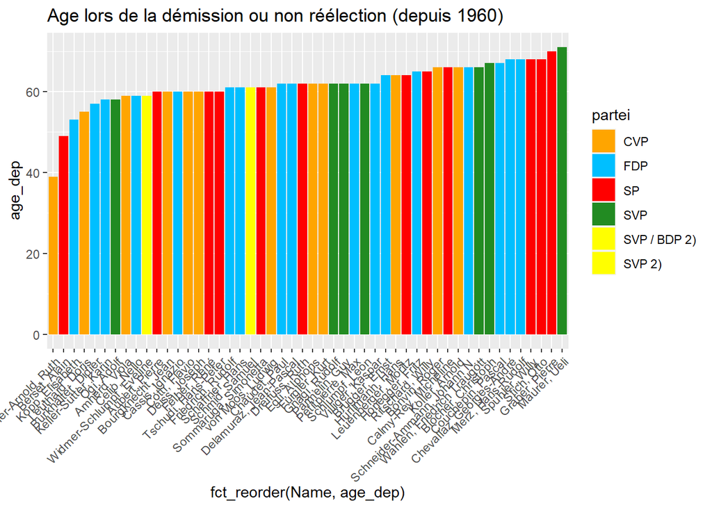

*Les plus jeunes* Si plusieurs ont démissionné au même âge, faire une recherche complémentaire pour savoir qui était le plus jeune d’entre eux

| Name | Bürgerort | Kanton | partei | age_dep | Gewählt | Zurückgetreten |
| --- | --- | --- | --- | --- | --- | --- |
| Metzler-Arnold, Ruth | Willisau, Richenthal und Balgach | AI | CVP | 39 | 1999-03-11 | 2003-12-31 |
| Berset, Alain | Misery-Courtion | FR | SP | 49 | 2011-12-14 | 2021-01-27 |
| Kopp, Elisabeth | Niederönz, Luzern und Zumikon | ZH | FDP | 53 | 1984-10-02 | 1989-01-12 |
| Leuthard, Doris | Merenschwand, Sarnen | AG | CVP | 55 | 2006-06-14 | 2018-12-31 |
| Burkhalter, Didier | Neuchâtel, Sumiswald | NE | FDP | 57 | 2009-09-16 | 2017-10-31 |
| Ogi, Adolf | Kandersteg | BE | SVP | 58 | 1987-12-09 | 2000-12-31 |
| Keller-Sutter, Karin | Kirchberg, Jonschwil | SG | FDP | 58 | 2018-12-05 | 2021-01-27 |
| Celio, Nello | Quinto (Lev.) | TI | FDP | 59 | 1966-12-15 | 1973-12-31 |
| Widmer-Schlumpf, Eveline | Felsberg, Mönchaltorf | GR | SVP / BDP 2) | 59 | 2007-12-12 | 2015-12-31 |
| Amherd, Viola | Brigue, Zwischbergen, Naters | VS | CVP | 59 | 2018-12-05 | 2021-01-27 |
| Bourgknecht, Jean | Fribourg | FR | CVP | 60 | 1959-12-17 | 1962-09-30 |
| Tschudi, Hans-Peter | Schwanden u. Basel | BS | SP | 60 | 1959-12-17 | 1973-12-31 |
| Aubert, Pierre | Savagnier | NE | SP | 60 | 1977-12-07 | 1987-12-31 |
| Cotti, Flavio | Prato Sornico | TI | CVP | 60 | 1986-12-10 | 1999-04-30 |
| Felber, René | Kottwil und Le Locle | NE | SP | 60 | 1987-12-09 | 1993-03-31 |
| Deiss, Joseph | Zeihen | FR | CVP | 60 | 1999-03-11 | 2006-07-31 |
| Cassis, Ignazio | Biasca, Sessa | TI | FDP | 60 | 2017-09-20 | 2021-01-27 |
| von Moos, Ludwig | Sachseln | OW | CVP | 61 | 1959-12-17 | 1971-12-31 |
| Schaffner, Hans | Gränichen | AG | FDP | 61 | 1961-06-15 | 1969-12-31 |
| Friedrich, Rudolf | Winterthur | ZH | FDP | 61 | 1982-12-08 | 1984-10-20 |

*Les plus vieux* Si plusieurs ont démissionné au même âge, faire une recherche complémentaire pour savoir qui était le plus vieux d’entre eux

| Name | Bürgerort | Kanton | partei | age_dep | Gewählt | Zurückgetreten | deces_pouvoir |
| --- | --- | --- | --- | --- | --- | --- | --- |
| Maurer, Ueli | Adelboden, Hinwil | ZH | SVP | 71 | 2008-12-10 | 2021-01-27 | Non |
| Graber, Pierre | Langenbruck und La Chaux-de-Fonds | NE | SP | 70 | 1969-12-10 | 1978-01-31 | Non |
| Spühler, Willy | Zürich | ZH | SP | 68 | 1959-12-17 | 1970-01-31 | Non |
| Chevallaz, Georges-André | Montherod | VD | FDP | 68 | 1973-12-05 | 1983-12-31 | Non |
| Stich, Otto | Kleinlützel | SO | SP | 68 | 1983-12-07 | 1995-10-31 | Non |
| Merz, Hans-Rudolf | Beinwil am See | AR | FDP | 68 | 2003-12-10 | 2010-10-01 | Non |
| Couchepin, Pascal | Martigny | VS | FDP | 67 | 1998-03-11 | 2009-10-31 | Non |
| Blocher, Christoph | Meilen, Zürich, Schattenhalb | ZH | SVP | 67 | 2003-12-10 | 2007-12-31 | Non |
| Wahlen, Friedrich Traugott | Trimstein u. Bern | BE | SVP | 66 | 1958-12-11 | 1965-12-31 | Non |
| Bonvin, Roger | Icogne-Lens, Chermignon et Nendaz | VS | CVP | 66 | 1962-09-27 | 1973-12-31 | Non |
| Koller, Arnold | Gossau u. Oberbüren | AI | CVP | 66 | 1986-12-10 | 1999-04-30 | Non |
| Calmy-Rey, Micheline | Chermignon | GE | SP | 66 | 2002-12-04 | 2011-12-31 | Non |
| Schneider-Ammann, Johann N. | Hasle bei Burgdorf | BE | FDP | 66 | 2010-09-22 | 2018-12-31 | Non |
| Ritschard, Willy | Oberhofen u. Luterbach | SO | SP | 65 | 1973-12-05 | 1983-10-03 | Non |
| Honegger, Fritz | Fischenthal u. Rüschlikon | ZH | FDP | 65 | 1977-12-07 | 1982-12-31 | Non |
| Brugger, Ernst | Möriken und Grossau | ZH | FDP | 64 | 1969-12-10 | 1978-01-31 | Non |
| Hürlimann, Hans | Walchwil | ZG | CVP | 64 | 1973-12-05 | 1982-12-31 | Non |
| Leuenberger, Moritz | Rohrbach | ZH | SP | 64 | 1995-09-27 | 2010-10-31 | Non |
| Petitpierre, Max | Neuchâtel et Couvet | NE | FDP | 62 | 1944-12-14 | 1961-06-30 | Non |
| Chaudet, Paul | Corsier s. Vevey | VD | FDP | 62 | 1954-12-16 | 1966-12-31 | Non |

**Répartition des départements entre les partis** A prendre avec des pincettes car les calculs se basent sur des chiffres arrondis à l’année figurant sur le site de la Chancellerie fédérale. La tendance est correcte mais peut-être pas le chiffre exact.

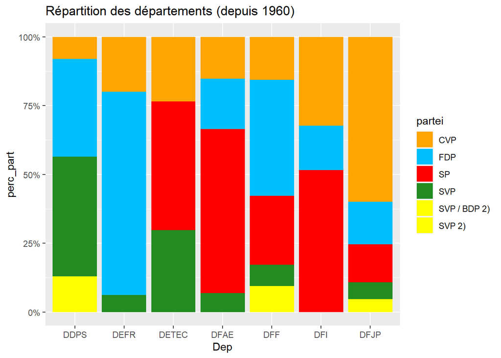

**Le plus longtemps au sein d’un même département**

| Name | Kanton | partei | Dep | duree |
| --- | --- | --- | --- | --- |
| Leuenberger, Moritz | ZH | SP | DETEC | 16 |
| Tschudi, Hans-Peter | BS | SP | DFI | 14 |
| Gnägi, Rudolf | BE | SVP | DDPS | 12 |
| Delamuraz, Jean-Pascal | VD | FDP | DEFR | 12 |
| von Moos, Ludwig | OW | CVP | DFJP | 12 |
| Stich, Otto | SO | SP | DFF | 12 |
| Furgler, Kurt | SG | CVP | DFJP | 11 |
| Koller, Arnold | AI | CVP | DFJP | 11 |
| Aubert, Pierre | NE | SP | DFAE | 10 |
| Leuthard, Doris | AG | CVP | DETEC | 9 |
| Schaffner, Hans | AG | FDP | DEFR | 9 |
| Brugger, Ernst | ZH | FDP | DEFR | 9 |
| Sommaruga, Simonetta | BE | SP | DFJP | 9 |
| Hürlimann, Hans | ZG | CVP | DFI | 9 |
| Dreifuss, Ruth | GE | SP | DFI | 9 |
| Berset, Alain | FR | SP | DFI | 9 |
| Graber, Pierre | NE | SP | DFAE | 9 |
| Calmy-Rey, Micheline | GE | SP | DFAE | 9 |
| Schlumpf, Leon | GR | SVP | DETEC | 8 |
| Ogi, Adolf | BE | SVP | DETEC | 8 |

**Nombre** **moyen** **d’années** **d’un** **conseiller** **fédéral** **par** **parti**

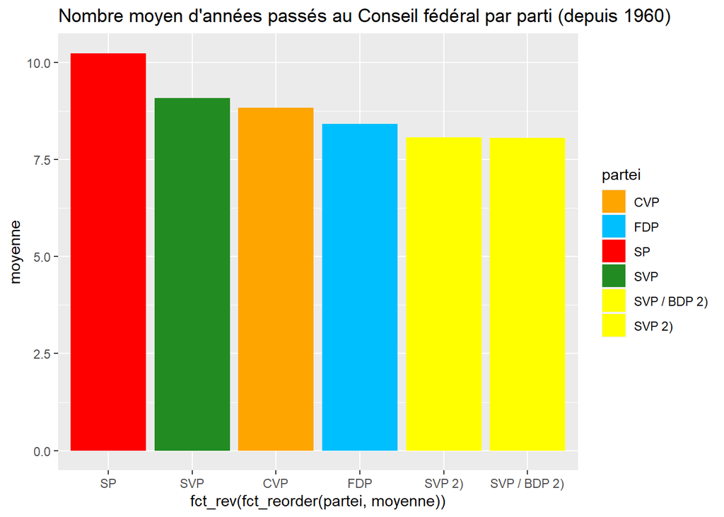

| partei | moyenne |
| --- | --- |
| SP | 10.245000 |
| SVP | 9.088571 |
| CVP | 8.835000 |
| FDP | 8.427647 |
| SVP 2) | 8.070000 |
| SVP / BDP 2) | 8.060000 |

## **DEPUIS 1979** (QUARANTE DERNIERES ANNEES)

### Nombre d’années passées au Conseil fédéral

| Name | Kanton | partei | duree | deces_pouvoir | Gewählt | Zurückgetreten | Gestorben | Geboren | Bürgerort |
| --- | --- | --- | --- | --- | --- | --- | --- | --- | --- |
| Leuenberger, Moritz | ZH | SP | 15.10 | Non | 1995-09-27 | 2010-10-31 | NA | 1946 | Rohrbach |
| Villiger, Kaspar | LU | FDP | 14.92 | Non | 1989-02-01 | 2003-12-31 | NA | 1941 | Sins und Pfeffikon |
| Delamuraz, Jean-Pascal | VD | FDP | 14.32 | Non | 1983-12-07 | 1998-03-30 | 1998-10-04 | 1936 | Longirod |
| Gnägi, Rudolf | BE | SVP | 14.07 | Non | 1965-12-08 | 1979-12-31 | 1985-04-20 | 1917 | Schwadernau |
| Ogi, Adolf | BE | SVP | 13.07 | Non | 1987-12-09 | 2000-12-31 | NA | 1942 | Kandersteg |
| Leuthard, Doris | AG | CVP | 12.56 | Non | 2006-06-14 | 2018-12-31 | NA | 1963 | Merenschwand, Sarnen |
| Koller, Arnold | AI | CVP | 12.39 | Non | 1986-12-10 | 1999-04-30 | NA | 1933 | Gossau u. Oberbüren |
| Cotti, Flavio | TI | CVP | 12.39 | Non | 1986-12-10 | 1999-04-30 | NA | 1939 | Prato Sornico |
| Maurer, Ueli | ZH | SVP | 12.14 | Non | 2008-12-10 | 2021-01-27 | NA | 1950 | Adelboden, Hinwil |
| Stich, Otto | SO | SP | 11.91 | Non | 1983-12-07 | 1995-10-31 | 2012-09-12 | 1927 | Kleinlützel |
| Couchepin, Pascal | VS | FDP | 11.65 | Non | 1998-03-11 | 2009-10-31 | NA | 1942 | Martigny |
| Sommaruga, Simonetta | BE | SP | 10.36 | Non | 2010-09-22 | 2021-01-27 | NA | 1960 | Lugano, Eggiwil |
| Dreifuss, Ruth | GE | SP | 9.82 | Non | 1993-03-10 | 2002-12-31 | NA | 1940 | Endingen |
| Berset, Alain | FR | SP | 9.13 | Non | 2011-12-14 | 2021-01-27 | NA | 1972 | Misery-Courtion |
| Calmy-Rey, Micheline | GE | SP | 9.08 | Non | 2002-12-04 | 2011-12-31 | NA | 1945 | Chermignon |
| Schneider-Ammann, Johann N. | BE | FDP | 8.28 | Non | 2010-09-22 | 2018-12-31 | NA | 1952 | Hasle bei Burgdorf |
| Burkhalter, Didier | NE | FDP | 8.13 | Non | 2009-09-16 | 2017-10-31 | NA | 1960 | Neuchâtel, Sumiswald |
| Schlumpf, Leon | GR | SVP | 8.08 | Non | 1979-12-05 | 1987-12-31 | 2012-07-07 | 1925 | Mönchaltdorf u. Felsberg |
| Schmid, Samuel | BE | SVP 2) | 8.07 | Non | 2000-12-06 | 2008-12-31 | NA | 1947 | Attiswil |
| Widmer-Schlumpf, Eveline | GR | SVP / BDP 2) | 8.06 | Non | 2007-12-12 | 2015-12-31 | NA | 1956 | Felsberg, Mönchaltorf |
| Deiss, Joseph | FR | CVP | 7.39 | Non | 1999-03-11 | 2006-07-31 | NA | 1946 | Zeihen |
| Merz, Hans-Rudolf | AR | FDP | 6.81 | Non | 2003-12-10 | 2010-10-01 | NA | 1942 | Beinwil am See |
| Felber, René | NE | SP | 5.31 | Non | 1987-12-09 | 1993-03-31 | NA | 1933 | Kottwil und Le Locle |
| Parmelin, Guy | VD | SVP | 5.14 | Non | 2015-12-09 | 2021-01-27 | NA | 1959 | Bursins |
| Metzler-Arnold, Ruth | AI | CVP | 4.81 | Non | 1999-03-11 | 2003-12-31 | NA | 1964 | Willisau, Richenthal und Balgach |
| Kopp, Elisabeth | ZH | FDP | 4.28 | Non | 1984-10-02 | 1989-01-12 | NA | 1936 | Niederönz, Luzern und Zumikon |
| Egli, Alphons | LU | CVP | 4.07 | Non | 1982-12-08 | 1986-12-31 | 2016-08-05 | 1924 | Entlebuch u. Luzern |
| Blocher, Christoph | ZH | SVP | 4.06 | Non | 2003-12-10 | 2007-12-31 | NA | 1940 | Meilen, Zürich, Schattenhalb |
| Cassis, Ignazio | TI | FDP | 3.36 | Non | 2017-09-20 | 2021-01-27 | NA | 1961 | Biasca, Sessa |
| Amherd, Viola | VS | CVP | 2.15 | Non | 2018-12-05 | 2021-01-27 | NA | 1962 | Brigue, Zwischbergen, Naters |
| Keller-Sutter, Karin | SG | FDP | 2.15 | Non | 2018-12-05 | 2021-01-27 | NA | 1963 | Kirchberg, Jonschwil |
| Friedrich, Rudolf | ZH | FDP | 1.87 | Non | 1982-12-08 | 1984-10-20 | 2013-10-15 | 1923 | Winterthur |

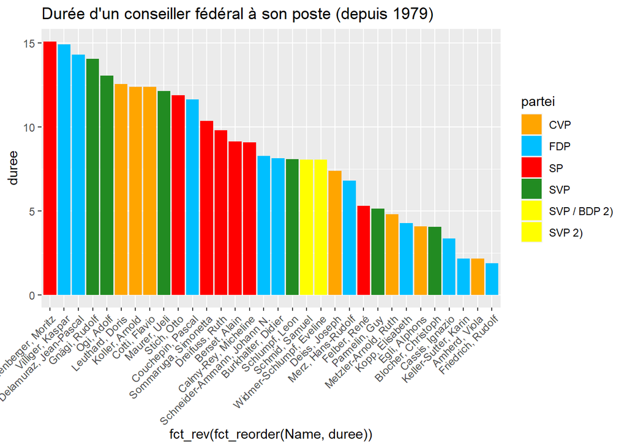

**Canton d’un conseiller fédéral**

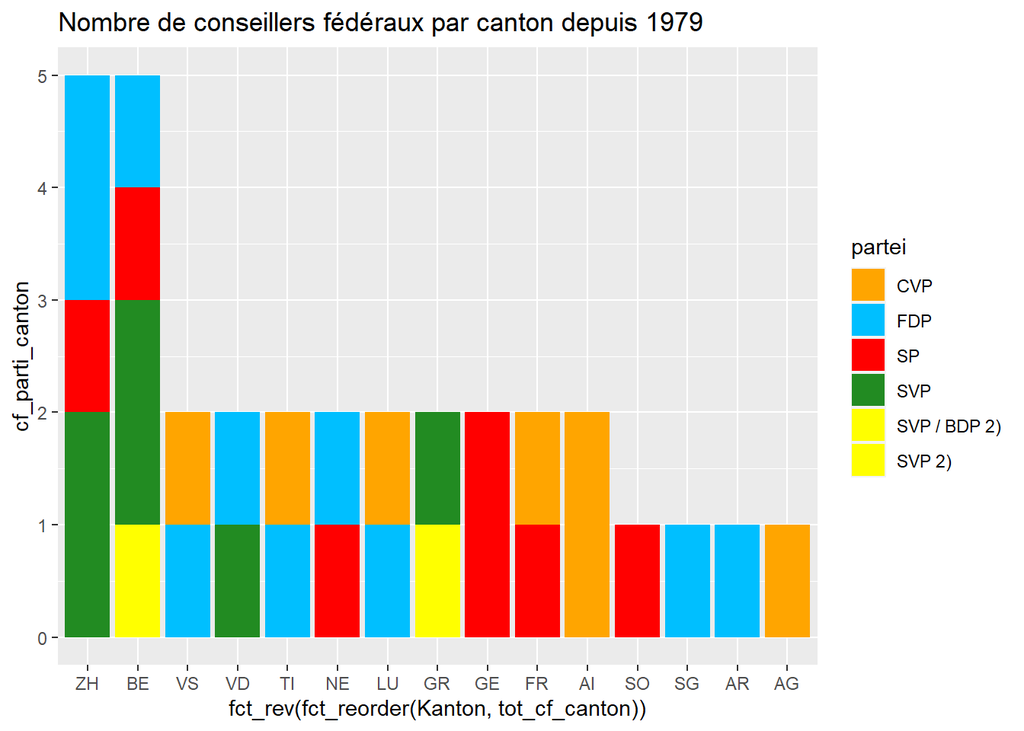

**Age lors de l’élection**

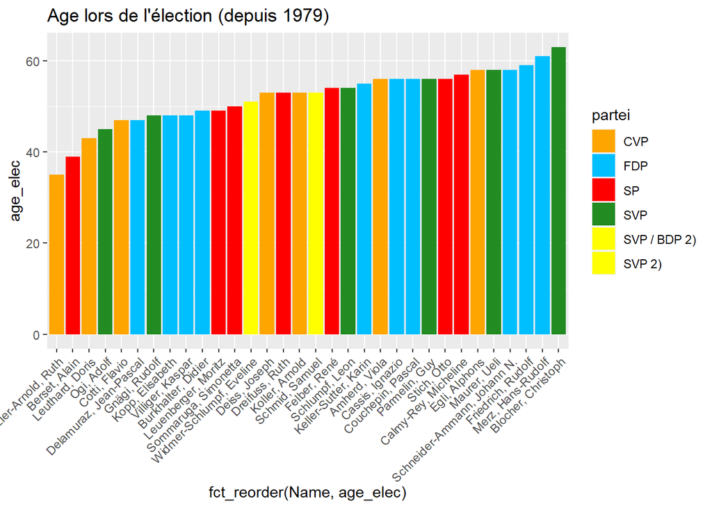

*Les plus jeunes* Si plusieurs ont été élus au même âge, faire une recherche complémentaire pour savoir qui était le plus jeune d’entre eux

| Name | Bürgerort | Kanton | partei | age_elec | Gewählt |
| --- | --- | --- | --- | --- | --- |
| Metzler-Arnold, Ruth | Willisau, Richenthal und Balgach | AI | CVP | 35 | 1999-03-11 |
| Berset, Alain | Misery-Courtion | FR | SP | 39 | 2011-12-14 |
| Leuthard, Doris | Merenschwand, Sarnen | AG | CVP | 43 | 2006-06-14 |
| Ogi, Adolf | Kandersteg | BE | SVP | 45 | 1987-12-09 |
| Delamuraz, Jean-Pascal | Longirod | VD | FDP | 47 | 1983-12-07 |
| Cotti, Flavio | Prato Sornico | TI | CVP | 47 | 1986-12-10 |
| Gnägi, Rudolf | Schwadernau | BE | SVP | 48 | 1965-12-08 |
| Kopp, Elisabeth | Niederönz, Luzern und Zumikon | ZH | FDP | 48 | 1984-10-02 |
| Villiger, Kaspar | Sins und Pfeffikon | LU | FDP | 48 | 1989-02-01 |
| Leuenberger, Moritz | Rohrbach | ZH | SP | 49 | 1995-09-27 |
| Burkhalter, Didier | Neuchâtel, Sumiswald | NE | FDP | 49 | 2009-09-16 |
| Sommaruga, Simonetta | Lugano, Eggiwil | BE | SP | 50 | 2010-09-22 |
| Widmer-Schlumpf, Eveline | Felsberg, Mönchaltorf | GR | SVP / BDP 2) | 51 | 2007-12-12 |
| Koller, Arnold | Gossau u. Oberbüren | AI | CVP | 53 | 1986-12-10 |
| Dreifuss, Ruth | Endingen | GE | SP | 53 | 1993-03-10 |
| Deiss, Joseph | Zeihen | FR | CVP | 53 | 1999-03-11 |
| Schmid, Samuel | Attiswil | BE | SVP 2) | 53 | 2000-12-06 |
| Schlumpf, Leon | Mönchaltdorf u. Felsberg | GR | SVP | 54 | 1979-12-05 |
| Felber, René | Kottwil und Le Locle | NE | SP | 54 | 1987-12-09 |
| Keller-Sutter, Karin | Kirchberg, Jonschwil | SG | FDP | 55 | 2018-12-05 |

*Les plus vieux* Si plusieurs ont été élus au même âge, faire une recherche complémentaire pour savoir qui était le plus vieux d’entre eux

[output not shown]

**Age lors de la démission/non-rélection** (attention: prend en compte les conseillers fédéraux encore au pouvoir)

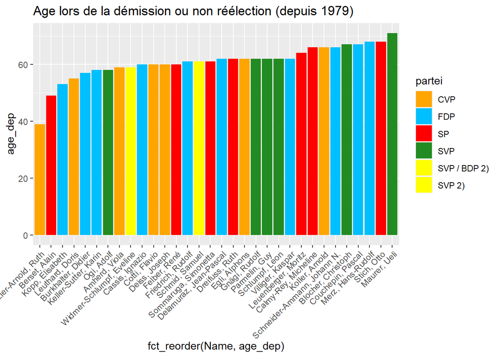

*Les plus jeunes* Si plusieurs n’ont pas été réélus ou ont démissionné au même âge, faire une recherche complémentaire pour savoir qui était le plus jeune d’entre eux

| Name | Geboren | Bürgerort | Kanton | partei | age_dep |
| --- | --- | --- | --- | --- | --- |
| Metzler-Arnold, Ruth | 1964 | Willisau, Richenthal und Balgach | AI | CVP | 39 |
| Berset, Alain | 1972 | Misery-Courtion | FR | SP | 49 |
| Kopp, Elisabeth | 1936 | Niederönz, Luzern und Zumikon | ZH | FDP | 53 |
| Leuthard, Doris | 1963 | Merenschwand, Sarnen | AG | CVP | 55 |
| Burkhalter, Didier | 1960 | Neuchâtel, Sumiswald | NE | FDP | 57 |
| Ogi, Adolf | 1942 | Kandersteg | BE | SVP | 58 |
| Keller-Sutter, Karin | 1963 | Kirchberg, Jonschwil | SG | FDP | 58 |
| Widmer-Schlumpf, Eveline | 1956 | Felsberg, Mönchaltorf | GR | SVP / BDP 2) | 59 |
| Amherd, Viola | 1962 | Brigue, Zwischbergen, Naters | VS | CVP | 59 |
| Cotti, Flavio | 1939 | Prato Sornico | TI | CVP | 60 |
| Felber, René | 1933 | Kottwil und Le Locle | NE | SP | 60 |
| Deiss, Joseph | 1946 | Zeihen | FR | CVP | 60 |
| Cassis, Ignazio | 1961 | Biasca, Sessa | TI | FDP | 60 |
| Friedrich, Rudolf | 1923 | Winterthur | ZH | FDP | 61 |
| Schmid, Samuel | 1947 | Attiswil | BE | SVP 2) | 61 |
| Sommaruga, Simonetta | 1960 | Lugano, Eggiwil | BE | SP | 61 |
| Gnägi, Rudolf | 1917 | Schwadernau | BE | SVP | 62 |
| Schlumpf, Leon | 1925 | Mönchaltdorf u. Felsberg | GR | SVP | 62 |
| Egli, Alphons | 1924 | Entlebuch u. Luzern | LU | CVP | 62 |
| Delamuraz, Jean-Pascal | 1936 | Longirod | VD | FDP | 62 |

*Les plus vieux* Si plusieurs n’ont pas été réélus ou ont démissionné au même âge, faire une recherche complémentaire pour savoir qui était le plus vieux d’entre eux

| Name | Geboren | Bürgerort | Kanton | partei | age_dep |
| --- | --- | --- | --- | --- | --- |
| Maurer, Ueli | 1950 | Adelboden, Hinwil | ZH | SVP | 71 |
| Stich, Otto | 1927 | Kleinlützel | SO | SP | 68 |
| Merz, Hans-Rudolf | 1942 | Beinwil am See | AR | FDP | 68 |
| Couchepin, Pascal | 1942 | Martigny | VS | FDP | 67 |
| Blocher, Christoph | 1940 | Meilen, Zürich, Schattenhalb | ZH | SVP | 67 |
| Koller, Arnold | 1933 | Gossau u. Oberbüren | AI | CVP | 66 |
| Calmy-Rey, Micheline | 1945 | Chermignon | GE | SP | 66 |
| Schneider-Ammann, Johann N. | 1952 | Hasle bei Burgdorf | BE | FDP | 66 |
| Leuenberger, Moritz | 1946 | Rohrbach | ZH | SP | 64 |
| Gnägi, Rudolf | 1917 | Schwadernau | BE | SVP | 62 |
| Schlumpf, Leon | 1925 | Mönchaltdorf u. Felsberg | GR | SVP | 62 |
| Egli, Alphons | 1924 | Entlebuch u. Luzern | LU | CVP | 62 |
| Delamuraz, Jean-Pascal | 1936 | Longirod | VD | FDP | 62 |
| Villiger, Kaspar | 1941 | Sins und Pfeffikon | LU | FDP | 62 |
| Dreifuss, Ruth | 1940 | Endingen | GE | SP | 62 |
| Parmelin, Guy | 1959 | Bursins | VD | SVP | 62 |
| Friedrich, Rudolf | 1923 | Winterthur | ZH | FDP | 61 |
| Schmid, Samuel | 1947 | Attiswil | BE | SVP 2) | 61 |
| Sommaruga, Simonetta | 1960 | Lugano, Eggiwil | BE | SP | 61 |
| Cotti, Flavio | 1939 | Prato Sornico | TI | CVP | 60 |

**Répartition des départements (depuis 1979)** A prendre avec des pincettes car les calculs se basent sur des chiffres arrondis à l’année figurant sur le site de la Chancellerie fédérale. La tendance est correcte mais peut-être pas le chiffre exact.

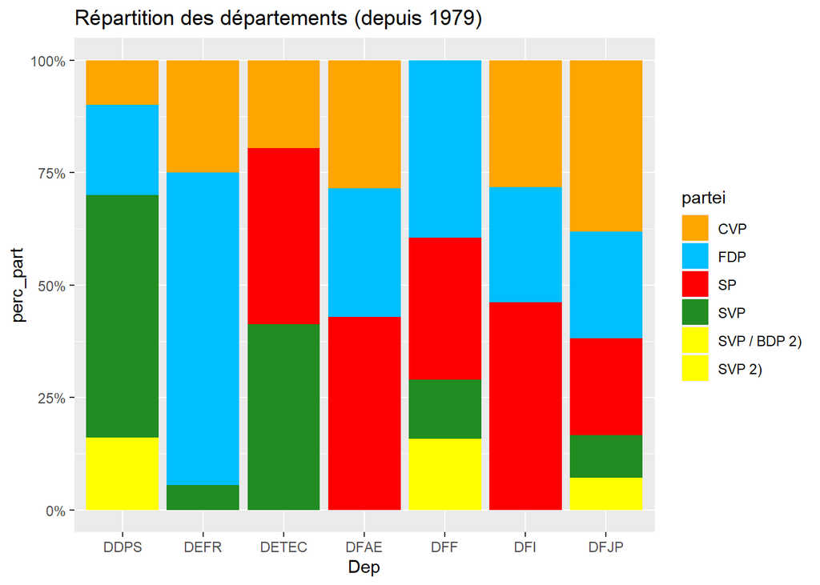

**Le plus longtemps au sein d’un département**

| Name | Kanton | partei | Dep | duree |
| --- | --- | --- | --- | --- |
| Leuenberger, Moritz | ZH | SP | DETEC | 16 |
| Gnägi, Rudolf | BE | SVP | DDPS | 12 |
| Delamuraz, Jean-Pascal | VD | FDP | DEFR | 12 |
| Stich, Otto | SO | SP | DFF | 12 |
| Koller, Arnold | AI | CVP | DFJP | 11 |
| Leuthard, Doris | AG | CVP | DETEC | 9 |
| Sommaruga, Simonetta | BE | SP | DFJP | 9 |
| Dreifuss, Ruth | GE | SP | DFI | 9 |
| Berset, Alain | FR | SP | DFI | 9 |
| Calmy-Rey, Micheline | GE | SP | DFAE | 9 |
| Schlumpf, Leon | GR | SVP | DETEC | 8 |
| Ogi, Adolf | BE | SVP | DETEC | 8 |
| Schmid, Samuel | BE | SVP 2) | DDPS | 8 |
| Schneider-Ammann, Johann N. | BE | FDP | DEFR | 8 |
| Villiger, Kaspar | LU | FDP | DFF | 8 |
| Villiger, Kaspar | LU | FDP | DDPS | 7 |
| Maurer, Ueli | ZH | SVP | DDPS | 7 |
| Merz, Hans-Rudolf | AR | FDP | DFF | 7 |
| Cotti, Flavio | TI | CVP | DFI | 7 |
| Couchepin, Pascal | VS | FDP | DFI | 7 |
| Kopp, Elisabeth | ZH | FDP | DFJP | 6 |
| Widmer-Schlumpf, Eveline | GR | SVP / BDP 2) | DFF | 6 |
| Cotti, Flavio | TI | CVP | DFAE | 6 |
| Felber, René | NE | SP | DFAE | 6 |
| Burkhalter, Didier | NE | FDP | DFAE | 6 |
| Ogi, Adolf | BE | SVP | DDPS | 5 |
| Couchepin, Pascal | VS | FDP | DEFR | 5 |
| Leuthard, Doris | AG | CVP | DEFR | 5 |
| Metzler-Arnold, Ruth | AI | CVP | DFJP | 5 |
| Maurer, Ueli | ZH | SVP | DFF | 5 |
| Deiss, Joseph | FR | CVP | DEFR | 4 |
| Blocher, Christoph | ZH | SVP | DFJP | 4 |
| Egli, Alphons | LU | CVP | DFI | 4 |
| Deiss, Joseph | FR | CVP | DFAE | 4 |
| Cassis, Ignazio | TI | FDP | DFAE | 4 |
| Gnägi, Rudolf | BE | SVP | DETEC | 3 |
| Delamuraz, Jean-Pascal | VD | FDP | DDPS | 3 |
| Koller, Arnold | AI | CVP | DDPS | 3 |
| Parmelin, Guy | VD | SVP | DDPS | 3 |
| Widmer-Schlumpf, Eveline | GR | SVP / BDP 2) | DFJP | 3 |
| Burkhalter, Didier | NE | FDP | DFI | 3 |
| Sommaruga, Simonetta | BE | SP | DETEC | 2 |
| Amherd, Viola | VS | CVP | DDPS | 2 |
| Parmelin, Guy | VD | SVP | DEFR | 2 |
| Friedrich, Rudolf | ZH | FDP | DFJP | 2 |
| Keller-Sutter, Karin | SG | FDP | DFJP | 2 |

**Durée moyenne d’un conseiller fédéral par parti**

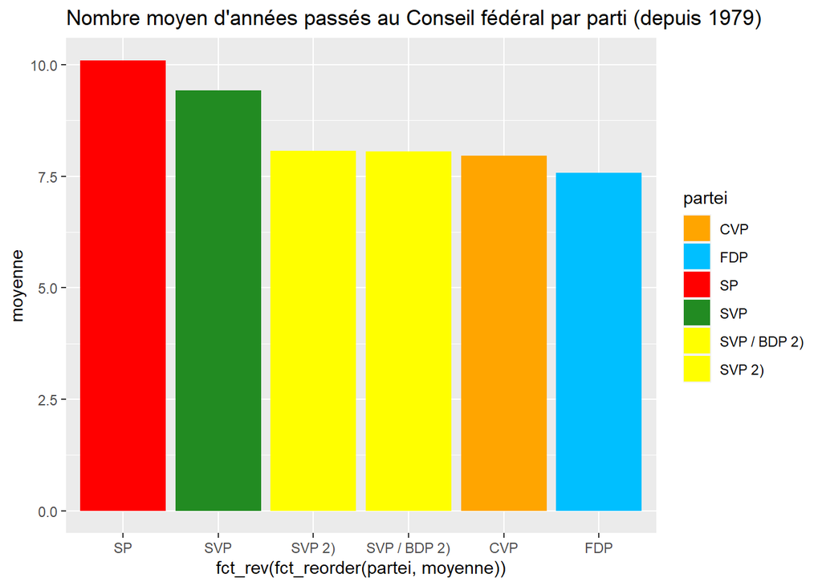

| partei | moyenne |
| --- | --- |
| SP | 10.101429 |
| SVP | 9.426667 |
| SVP 2) | 8.070000 |
| SVP / BDP 2) | 8.060000 |
| CVP | 7.965714 |
| FDP | 7.577000 |